# 第4回 人間の代役をコードで作る

## R3・R4 の位置の写経と実行

1. **＋ コード**で空の  
   セルを足す
2. p.83 の 7 行を上から写す
3. **▶** か **Shift + Enter** で実行  
   （Mac は Shift + return）
4. 2 組とも、教室との差の  
   R3 が大きいのを見る

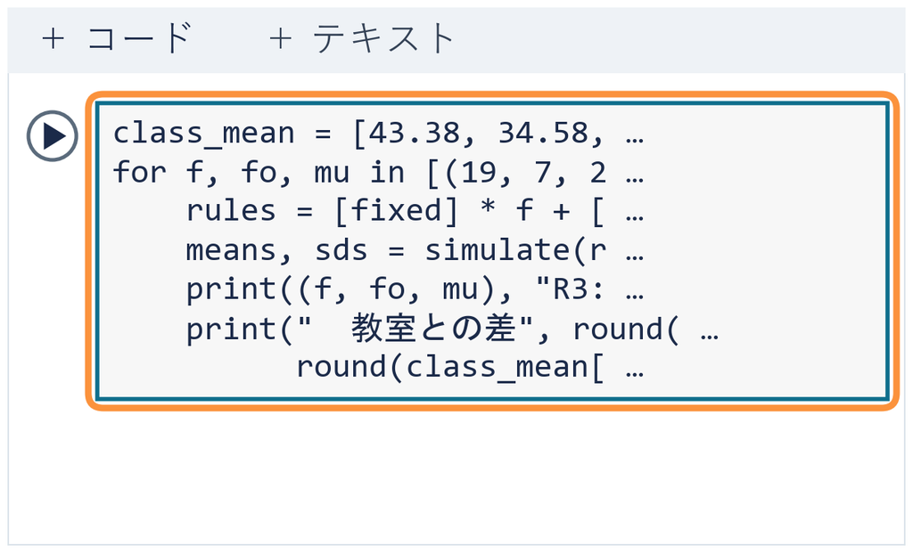

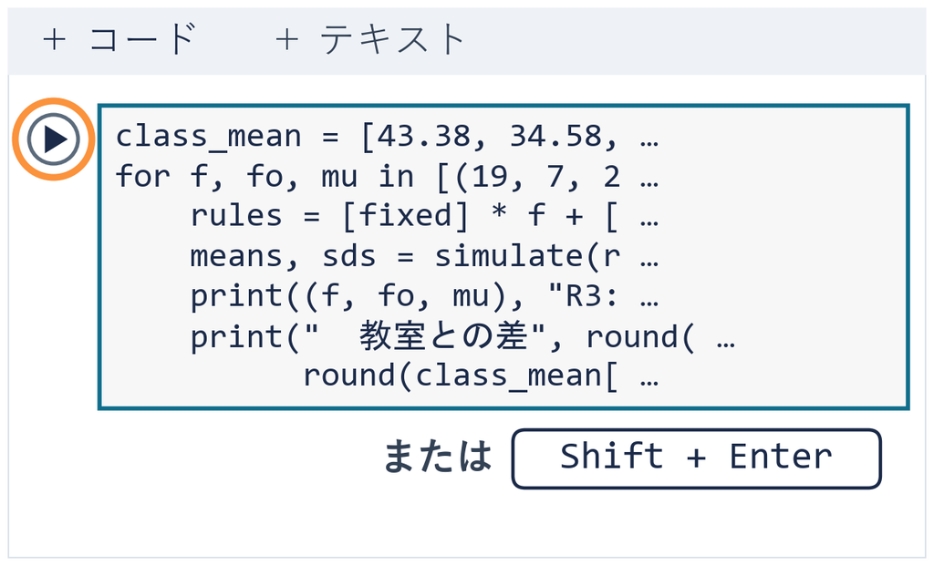

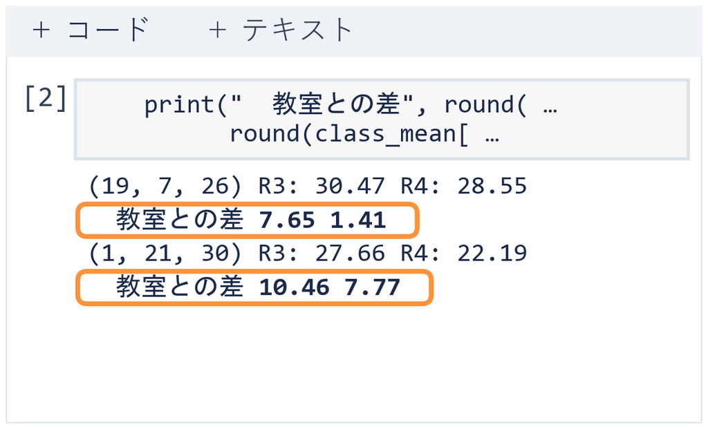

⏸ PAUSE 動画を止めて $3$ 分。4 行が出たら再生に戻る

## 演習 4 合う 2 組の R3 と R4

2026年度のデータ

演習 4

自分の 2 組は、R3・R4 で教室に合うか（小課題の段 4）

```python
class_mean = [43.38, 34.58, 38.12, 29.96]   # 教室の R1〜R4 の平均
for f, fo, mu in [(19, 7, 26), (1, 21, 30)]:  # ここを自分の 2 組に
    ...   # 3〜7 行目は p.83 と同じ（コピーして貼る）
```

1. **新しいセルで変える**：2 行目の 2 組を、自分の 2 組に
2. **自分の 2 組**：デモで見つけた組と、A か B
3. **書く**：合った点・外れた点・言えないこと（例：書いた理由）

⏸ PAUSE 動画を止めて $6$ 分。2 組の差を出し、3 つの文を書いたら再生に戻る

## 演習 4 の答えの例

2026年度のデータ

出力（例の 2 組）

(10, 13, 29) R3: 29.12 R4: 25.72 ／ 教室との差 9.0 4.24  
(19, 7, 26) R3: 30.47 R4: 28.55 ／ 教室との差 7.65 1.41

- **合った点**：R2 の平均。どちらも 34.59 で、合わせたとおり
- **外れた点**：教室は R3 で上がったのに、2 組とも下がる（差 9.0 と 7.65）
- **言えないこと**：教室の人がこのルールで考えていたか  
  R3 で上がった理由（100 を書いた人が 2 人 → 7 人）

A の R4 の差は 1.41 と小さい  
確かめる点を1つに絞ると、また合わせたのと同じになる

## まとめ

- **キャリブレーション**：結果に合うように決める
- **妥当性検証**：別の数・別の条件で確かめる
- **合う組は1つではない**：平均だけでは考え方は決まらない
- **合っても外れる**：R3 の上がりを作れない

ルールをコードにすると、集団の動きが計算できる  
ただし、合うことと、それが人の考え方であることは別